# As-a-Statistician-Survival Analysis

### Parameter test

**Wald Test**

$$\quad \hat{\beta} \sim N\left(\beta,\left(X^{T} W X\right)^{-1}\right)$$
**Likelihood Ratio Test**

Likelihood Ratio Test (LRT) is easy to use. LRT is often used to determine whether two models (different parameter dimensions) are significantly different. in particular
$$-2\left(l\left(\hat{\beta}_{1}\right)-l\left(\hat{\beta}_{2}\right)\right) \sim \chi_{p}^{2}, \quad$$

**Score Test**

It is very difficult to obtain the confidence interval with Score Method. But we can use it for hypothesis test
$$u(\beta)=\sum_{i=1}^{n} \delta_{i} x_{i}-\sum_{i=1}^{n} \sum_{k=1}^{n} Y_{k}\left(t_{i}\right) \frac{w_{k}}{\sum_{j=1}^{n} Y_{j}\left(t_{i}\right) w_{j}} x_{i} \delta_{i}=X^{T}(d-P d)$$
$$I(\beta)=\sum_{i=1}^{n} \sum_{k=1}^{n} \delta_{i} x_{i}\left[\frac{Y_{k}\left(t_{i}\right) w_{k}}{\sum_{j=1}^{n} Y_{j}\left(t_{i}\right) w_{j}} \frac{x_{k}^{T}\left(\sum_{j=1}^{n} Y_{j}\left(t_{i}\right) w_{j}\right)+\sum_{j=1}^{n} Y_{j}\left(t_{i}\right) w_{j} x_{j}^{T}}{\sum_{j=1}^{n} Y_{j}\left(t_{i}\right) w_{j}}\right]$$
The statistic is $u\left(\beta_{0}\right) / \sqrt{I\left(\beta_{0}\right)}$, there is no need to calculate $\hat{\beta}$ so as to add it to the model There is no need to refit the parameters for new variables.

### Graphs of the survival and baseline hazard function in SAS

**plots=survival**

When only plots=survival is specified on the proc phreg statement, SAS will produce one graph, a “reference curve” of the survival function at the reference level of all categorical predictors and at the mean of all continuous predictors.

```
proc phreg data=whas500 plots=survival;
    class gender;
    model lenfol*fstat(0) = gender age;;
run;
```

**Use the baseline statement to generate survival plots by group**

```
***Whether it is a survival curve or a hazad curve, it is necessary to use
   the baseline description and create a small data set of covariate values
   to estimate the curve of interest;
proc format;
    value gender 0 = "male" 1 = "female";
run;
data covs;
    format gender gender.;
    input gender age;
    datalines;
    0 69.845947
    1 69.845947
    ;
run;

*** covariates = option in baseline statement to specify the dataset
*** rowid = If a variable is specified after the option, SAS will create a separate
    line for each level of the variable in the same graph;

proc phreg data = whas500 plots(overlay)=(survival);
    class gender;
    model lenfol*fstat(0) = gender age;
    baseline covariates=covs out=base / rowid=gender;
run;
```

**hazardratio statement**

Using the hazardratio statement and graphs to interpret effects, particularly interactions. Below, we show how to use the hazardratio statement to request that SAS estimate 3 hazard ratios at specific levels of our covariates

- After the keyword hazardratio, we can optionally apply a label, then we specify the variable whose levels are to be compared in the hazard, and finally after the option keyword at we tell SAS at which level of our other covariates to evaluate this hazard ratio. If the variable whose hazard rates are to computed is not involved in an interaction, specification of additional covariates is unncessary since the hazard ratio is constant across levels of all other covariates (a main effect).
- We calculate the hazard ratio describing a one-unit increase in age, or **HR(age+1) HR(age)**, for both genders. Notice the =ALL following gender, which is used only with class variables to request the hazard ratio at all levels of the class variable.
- We also calculate the hazard ratio between females and males, or **HR(gender=1)HR(gender=0)** at ages 0, 20, 40, 60, and 80.
- Finally, we calculate the hazard ratio describing a 5-unit increase in bmi, or **HR(bmi+5) HR(bmi)**, at clinically revelant BMI scores. Notice the additional option units=5. BMI classes are typically separated by about 5 points, so we would like to see how the hazard ratio between (approximately) adjacent BMI classes changes as bmi increases.

```
proc phreg data = whas500;
    class gender;
    model lenfol*fstat(0) = gender|age bmi|bmi hr ;
    hazardratio 'Effect of 1-unit change in age by gender' age / at(gender=ALL);
    hazardratio 'Effect of gender across ages' gender / at(age=(0 20 40 60 80));
    hazardratio 'Effect of 5-unit change in bmi across bmi' bmi / at(bmi = (15 18.5 25 30 40)) units=5;
run;
```

| Effect of gender across ages: Hazard Ratios for GENDER | Title | Title | Title |
| --- | --- | --- | --- |
| Description | Point Estimate | 95% Wald CI Lower Limits | CI Upper Limits |
| GENDER Female vs Male At AGE=0 | 8.247 | 1.177 | 57.783 |
| GENDER Female vs Male At AGE=20 | 4.594 | 1.064 | 19.841 |
| GENDER Female vs Male At AGE=40 | 2.559 | 0.955 | 6.857 |
| GENDER Female vs Male At AGE=60 | 1.426 | 0.837 | 2.429 |
| GENDER Female vs Male At AGE=80 | 0.794 | 0.601 | 1.049 |

### Check proportional hazards

A central assumption of Cox regression is that covariate effects on the hazard rate, namely **hazard ratios, are constant over time**. For example, if males have twice the hazard rate of females 1 day after followup, the Cox model assumes that males have twice the hazard rate at 1000 days after follow up as well. Violations of the proportional hazard assumption may cause bias in the estimated coefficients as well as incorrect inference regarding significance of effects.

1. Graphing Kaplan-Meier survival function estimates to assess proportional hazards for categorical covariates
   - In the case of categorical covariates, graphs of the Kaplan-Meier estimates of the survival function provide quick and easy checks of proportional hazards. If proportional hazards holds, **the graphs of the survival function should look “parallel”**, in the sense that they should have basically the same shape, should not cross, and should start close and then diverge slowly through follow up time.
   - Another graphical methods for checking proportional hazards is to plot log(-log(S(t))) vs. t or log(t) and look for parallelism. This can be done only for categorical covariates

   ```
   proc lifetest data=whas500 atrisk plots=survival(atrisk cb) outs=outwhas500;
   strata gender;
   time lenfol*fstat(0);
   run;
   ```

2. Plotting scaled **Schoenfeld residuals** vs functions of time to assess proportional hazards of a continuous covariate
   - $$E(s^\star_{kp}) + \hat{\beta}_p \approx \beta_j(t_k)$$
   - $s^\star_{kp}$ is the scaled Schoenfeld residual of the covariate $p$ at time $k$, $\beta_p$ is the time-invariant coefficient, and $\beta_j(tk)$ is the time-varying coefficient. In other words, the average value of the Schoenfeld residual of the coefficient $k$ at time $k$ estimates the coefficient change at time $k$. Therefore, if the average value of the whole time is 0, it means that the coefficient $p$ will not change with time, and the proportional hazard assumption applies to the covariate $p$.

   ```
   proc phreg data=whas500;
   class gender;
   model lenfol*fstat(0) = gender|age bmi|bmi hr;
   output out=schoen ressch=schgender schage schgenderage
      schbmi schbmibmi schhr;
   run;

   data schoen;
      set schoen;
      loglenfol = log(lenfol);
   run;

   proc loess data = schoen;
      model schage=lenfol / smooth=(0.2 0.4 0.6 0.8);
   run;
   proc loess data = schoen;
      model schage=loglenfol / smooth=(0.2 0.4 0.6 0.8);
   run;
   ```

```r
res.cox <- coxph(Surv(time, status) ~ age + sex + wt.loss, data =  lung)
test.ph <- cox.zph(res.cox)
test.ph
```

```
##          chisq df    p
## age     0.5077  1 0.48
## sex     2.5489  1 0.11
## wt.loss 0.0144  1 0.90
## GLOBAL  3.0051  3 0.39
```

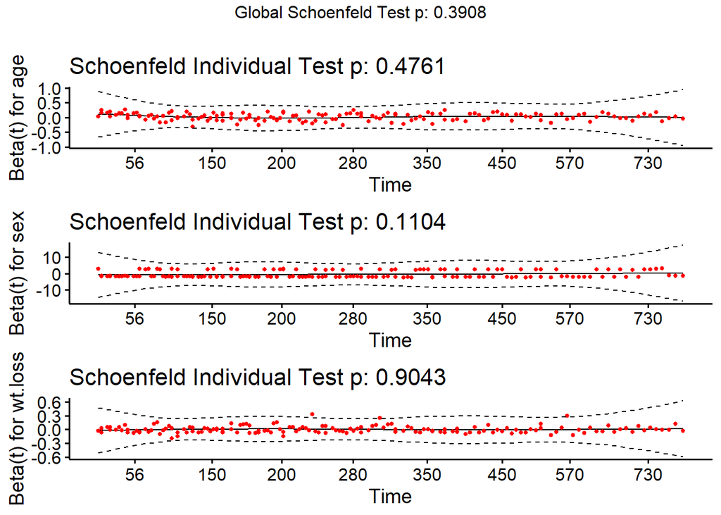

```r
## The test of each covariate is not statistically significant, and the global test is not statistically significant. Therefore, we can take proportional risk.

## In principle, Schoenfeld residuals have nothing to do with time. A chart showing a non-random graph showing time changes over time indicates a violation of the PH assumption

ggcoxzph(test.ph)
```

```r
## The solid line is the smooth spline fit of the curve, and the dashed line represents the +/- 2 standard error band around the fit. System deviation from the horizontal line indicates non-proportional hazard, because proportional hazard assumes that the estimated values β1, β2, and β3 do not change much over time.
```

3. Using assess with the ph option to check proportional hazards
   - Option ph tells SAS that in addition to checking the functional form, we also want to evaluate the proportional hazard. As before, we specify the resampling option to request the highest test of the null hypothesis that the proportional hazard holds. These tests calculate the proportion of simulated score processes that produce a maximum score greater than the observed maximum score process. A small percentage (p-value) indicates that the percentage is violated

   ```
   proc phreg data=whas500;
       class gender;
       model lenfol*fstat(0) = gender|age bmi|bmi hr;
       assess var=(age bmi bmi*bmi hr) ph / resample ;
   run;
   ```

   | Supremum Test for Proportionals Hazards Assumptio | Title | Title | Title | Title |
   | --- | --- | --- | --- | --- |
   | Variable | Maximum Absolute Value | Replications | Seed | Pr > MaxAbsVal |
   | GENDERFemale | 0.6394 | 1000 | 778428000 | 0.7680 |
   | AGE | 0.4965 | 1000 | 778428000 | 0.9600 |
   | BMI | 5.9813 | 1000 | 778428000 | 0.2890 |
   | BMIBMI | 5.9350 | 1000 | 778428000 | 0.3160 |
   | HR | 0.8861 | 1000 | 778428000 | 0.3080 |

### Dealing with nonproportionality

If nonproportional hazards are detected, the researcher has many options with how to address the violation (Therneau & Grambsch, 2000):

Ignore the nonproportionality if it appears the changes in the coefficient over time are very small or if it appears the outliers are driving the changes in the coefficient. In large datasets, very small departures from proportional hazards can be detected. If, say, a regression coefficient changes only by 1% over time, it is unlikely that any overarching conclusions of the study would be affected. Additionally, a few heavily influential points may be causing nonproportional hazards to be detected, so it is important to use graphical methods to ensure this is not the case.

**Stratify** the model by the nonproportional covariate. Stratification allows each stratum to have its own baseline hazard, which solves the problem of nonproportionality. However, one cannot test whether the stratifying variable itself affects the hazard rate significantly. Additionally, although stratifying by a categorical covariate works naturally, it is often difficult to know how to best discretize a continuous covariate. This can be easily accomplished in proc phreh with the strata statement.

### Model Diagnostics

#### Cox-Snell Residuals

The residual represents the part that the explanatory variable cannot explain, in the case of censoring
$$\hat{e}_{i}=\hat{\Lambda}_{0}\left(t_{i}\right) \exp \left(x_{i}^{T} \beta\right)$$

$\hat(\Lambda)$ can be estimated by $KM$ (or $NA$). Compare Cox-Snell Residuals with the standard exponential distribution, because $Y=\Lambda(t) \sim \operatorname(Exp)(1)]$ , Get the residual plot. However, this has a little flaw, because it is not easy for us to observe the situation close to the origin. Therefore, we use standardized difference for transformation.
$$(\hat{\Lambda}(e)-\Lambda(e)) / S E=(\hat{\Lambda}(e)-e) / S E$$
However, the Cox-Snell residual is flawed: it has no way to tell us where the assumptions of the model are wrong.

#### Martingale residuals

$$\hat{m}_{i}=\delta_{i}-\hat{\Lambda}_{i}\left(t_{i}\right)=\delta_{i}-\hat{e}_{i}$$

It represents the difference between the observed value of the sample death index $\left(\delta_{i}\right)$ and the average value $\left(\hat{e}_{i}\right)$. Among them, the average is about the average over time. Positive and negative are meaningful. Positive, it means that the patient died earlier than the expected time; negative, it means that the patient lived longer (or censored). But it is asymmetrical. The maximum value of $\quad \hat{m}_{i}$ is 1, but the minimum value is infinite.

#### Deviance Residuals

$$\hat{d}_{i}=\operatorname{sign}\left(\hat{m}_{i}\right) \sqrt{2\left(\tilde{l}_{i}-l_{i}\right)},$$

$\hat{m}_{i}=\delta_{i}-\hat{e}_{i}, \quad l_{i}$ is the corresponding likelihood of i sample (given model), $\tilde{l }_{i}$ represents the maximum likelihood (generally the full model). It retains the positive and negative nature of the residual error, and adds the idea of likelihood (in fact, many tests are based on deviance), which is symmetric.

#### Schoenfeld residuals

The Schoenfeld residual of the observation j and the covariate p is defined as the difference between the covariate p of the observation j and the weighted average of the covariate values of all subjects who are still at risk when the event occurs on the observation j.
$$E(s^\star_{kp}) + \hat{\beta}_p \approx \beta_j(t_k)$$

Schoenfeld Residuals are used to validate the above assumptions made by the Cox model. The Cox model makes three assumptions:

1. Common baseline hazard rate $\lambda(t)$ : At any time $t$, all individuals are assumed to experience the same baseline hazard $\lambda(t)$. For example, if a study consists of males and females belonging to different races and age groups, then at any time $t$ during the study, white males who entered the study when they were in the 18-34 years age range are assumed to experience the same baseline hazard $\lambda(t)$ as Asian females who entered the study when they $40-64$ year old. This is clearly a strong assumption and one must validate it before accepting results of the Cox model for your data set.
2. Time invariant co-variates $X$ : The effect of the regression variables $\boldsymbol{X}$ (a.k.a. co-variates) on the instantaneous hazard experienced by an individual is assumed to remain constant over time. For example, if a volunteer enters a study of cancer risk to smokers, and if the participant’s genetic makeup is a co-variate, then the effect of their genes on the hazard of contracting cancer is assumed to remain constant throughout the study. Notation-wise, $\boldsymbol{X}\left(t_{-} i\right)=\boldsymbol{X}$ for all $t_{-} i$. This is again a rather strong assumption that should be validated. For example, gene expression can vary with time in response to a number of factors.
3. Time invariant regression coefficients $\beta:$ The regression coefficients $\boldsymbol{\beta}$ do not vary with time. In other words, $\boldsymbol{\beta}\left(\mathrm{t}_{-} i\right)=\boldsymbol{\beta}$ for all $t_{-} i$. One can see that assumptions (2) and (3) are closely related. For example, the effect of gene expression increasing with time can be expressed as the coefficient of the gene regression variable increasing with time.

#### Testing influential observations

To test influential observations or outliers, we can visualize either:

- the deviance residuals or
- the dfbeta values

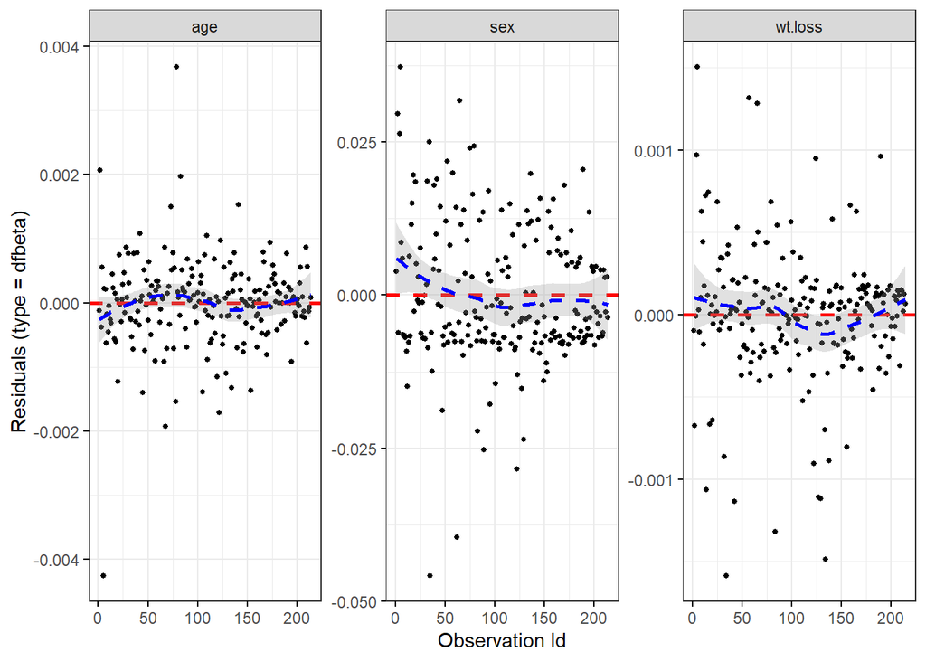

```r
## ggcoxdiagnostics(fit, type = , linear.predictions = TRUE)
## type: the type of residuals to present on Y axis. Allowed values include one of
## c(“martingale”, “deviance”, “score”, “schoenfeld”, “dfbeta”, “dfbetas”, “scaledsch”, “partial”).
ggcoxdiagnostics(res.cox, type = "dfbeta",
                 linear.predictions = FALSE, ggtheme = theme_bw())
```

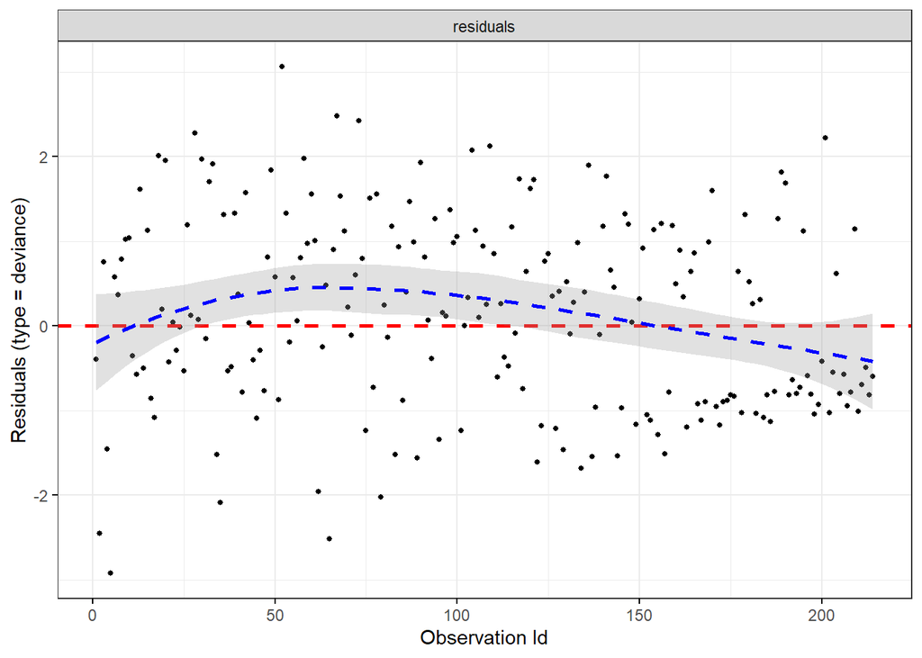

```r
ggcoxdiagnostics(res.cox, type = "deviance",
                 linear.predictions = FALSE, ggtheme = theme_bw())
```